# Proppit Analytics

### January 2023

# Analyze Proppit Data along these set criteria:

Popularity:

- Top Projects by Count of Leads
- Top Projects per Location
- Top Projects by Developer

Pricing and Types of Leads:

- Average Price of Leads
- Lead Status
- Type of Lead

Leads Distribution

- Count of Leads by Type and Price

Timelines

- Leads per Year
- Leads per Year 2022
- Leads per Year 2023
- Leads per Weekday

# Data Analysis

# Popularity:

- Top Projects by Count of Leads
- Top Projects by Location
- Top Projects by Developer

Top Projects by Count of Leads

[output not shown]

Top Projects by Location

|  | State | Count |
| --- | --- | --- |
| 0 | Bangkok | 588 |
| 1 | Chonburi | 53 |
| 2 | Pathum Thani | 15 |
| 3 | Phuket | 8 |
| 4 | Samut Prakan | 6 |
| 5 | Nonthaburi | 5 |
| 6 | Prachuap Khirikhan | 1 |

Top Districts in Bangkok

|  | District | Creation Date |
| --- | --- | --- |
| 0 | Wangthong Lang | 137 |
| 1 | Wattana | 114 |
| 2 | Ding Daeng | 52 |
| 3 | Phaya Thai | 52 |
| 4 | Bang Na | 23 |
| 5 | Phra Khanong | 23 |
| 6 | Bang Kapi | 21 |
| 7 | Bung Kum | 21 |
| 8 | Saphan Sung B39 | 21 |
| 9 | Bang Su | 14 |
| 10 | Nong Khaem | 9 |

Top Districts in Chonburi

|  | District | Creation Date |
| --- | --- | --- |
| 0 | Bang Lamung | 52 |
| 1 | Muang Chonburi | 1 |

Top Districts in Pathum Thani

|  | District | Creation Date |
| --- | --- | --- |
| 0 | Khlong Luang | 15 |

Top Districts in Phuket

|  | District | Creation Date |
| --- | --- | --- |
| 0 | Thalang | 7 |
| 1 | Kathu | 1 |

Top Projects by Developer

|  | index | Developer |
| --- | --- | --- |
| 0 | AP (Thai) | 41 |
| 1 | Major | 34 |
| 2 | Risland | 26 |
| 3 | ASSETWISE | 25 |
| 4 | Sansiri | 24 |
| 5 | Origin | 23 |
| 6 | Noble | 22 |
| 7 | Ananda | 20 |
| 8 | The Urban Property | 19 |
| 9 | Land and Houses | 16 |
| 10 | SENA | 12 |

### Developer by Developer Breakdown

AP (Thai)

|  | Developer | Project name | Creation Date |
| --- | --- | --- | --- |
| 0 | AP (Thai) | Life Asoke Hype | 32 |
| 1 | AP (Thai) | Life Rama 4 - Asoke | 5 |
| 2 | AP (Thai) | Life Sathorn Sierra | 3 |
| 3 | AP (Thai) | Life Ladprao Valley | 1 |

Major

|  | Developer | Project name | Creation Date |
| --- | --- | --- | --- |
| 0 | Major | Maestro 14 Siam - Ratchathewi | 22 |
| 1 | Major | M Jatujak | 8 |
| 2 | Major | Maru Ladprao 15 | 4 |

Risland

|  | Developer | Project name | Creation Date |
| --- | --- | --- | --- |
| 0 | Risland | Skyrise Avenue Sukhumvit 64 | 14 |
| 1 | Risland | The LIVIN Phetkasem | 12 |

Assetwise

|  | Developer | Project name | Creation Date |
| --- | --- | --- | --- |
| 0 | ASSETWISE | Atmoz Ladprao 71 | 10 |
| 1 | ASSETWISE | Kave Town Space | 7 |
| 2 | ASSETWISE | Kave Town Shift | 6 |
| 3 | ASSETWISE | Atmoz Chaengwattana | 2 |

Sansiri

|  | Developer | Project name | Creation Date |
| --- | --- | --- | --- |
| 0 | Sansiri | Edge Central Pattaya | 17 |
| 1 | Sansiri | Saransiri Srivaree | 3 |
| 2 | Sansiri | XT Phayathai | 2 |
| 3 | Sansiri | The Base Saphanmai | 2 |

Origin

|  | Developer | Project name | Creation Date |
| --- | --- | --- | --- |
| 0 | Origin | Origin Plug & Play Ramkhamhaeng Triple Station | 18 |
| 1 | Origin | The Origin Sukhumvit 105 | 4 |
| 2 | Origin | KnightsBridge Space Ratchayothin | 1 |

Noble

|  | Developer | Project name | Creation Date |
| --- | --- | --- | --- |
| 0 | Noble | Noble BE19 | 19 |
| 1 | Noble | Nue Noble Chaengwattana | 3 |

The Urban Property

|  | Developer | Project name | Creation Date |
| --- | --- | --- | --- |
| 0 | The Urban Property | Aeras | 15 |
| 1 | The Urban Property | Attitude Lasalle | 2 |
| 2 | The Urban Property | Attitude BU | 2 |

Ananda

|  | Developer | Project name | Creation Date |
| --- | --- | --- | --- |
| 0 | Ananda | COCO Parc | 8 |
| 1 | Ananda | Ideo Mobi Bangsue Grand Interchange | 5 |
| 2 | Ananda | Ideo Rama 9 - Asoke | 3 |
| 3 | Ananda | Ideo Q Victory | 2 |
| 4 | Ananda | Ideo Mobi Asoke | 1 |
| 5 | Ananda | Ashton Residence 41 | 1 |

Land and Houses

|  | Developer | Project name | Creation Date |
| --- | --- | --- | --- |
| 0 | Land and Houses | The Key MRT Phetkasem 48 | 12 |
| 1 | Land and Houses | The Bangkok Thonglor | 4 |

Sena

|  | Developer | Project name | Creation Date |
| --- | --- | --- | --- |
| 0 | SENA | Niche Mono Charoen Nakorn | 9 |
| 1 | SENA | Niche Mono Ramkhamhaeng | 3 |

# Pricing and Types of Leads:

- Average Price of Leads
- Lead Status
- Type of Lead

Average Price of Leads

```
8137603.86
```

Lead Status

|  | index | Status |
| --- | --- | --- |
| 0 | New | 655 |
| 1 | Contacted | 74 |
| 2 | Lost | 13 |

Type of Lead

|  | index | Operation type |
| --- | --- | --- |
| 0 | Sale | 721 |
| 1 | Rent | 21 |

Leads Distribution

Count of Leads by Type

|  | index | Property type |
| --- | --- | --- |
| 0 | Condo | 529 |
| 1 | Villa | 18 |
| 2 | Apartment | 8 |
| 3 | House | 6 |
| 4 | Hotel | 4 |
| 5 | Townhouse | 4 |

Price of Leads by Type

[output not shown]

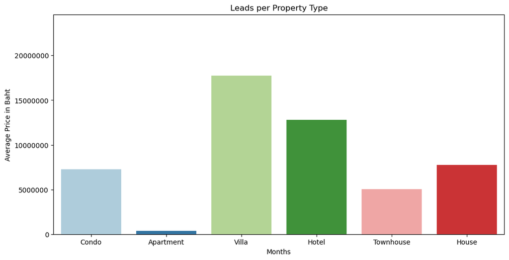

Most number of searches (by Email count)

|  | index | Email |
| --- | --- | --- |
| 0 | tanguy.thomas@gmail.com | 30 |
| 1 | paulcy0620@gmail.com | 13 |
| 2 | petersax@gmail.com | 12 |
| 3 | lawrencethet@gmail.com | 9 |
| 4 | bakethar1992@gmail.com | 8 |
| 5 | pachsiry@hotmail.com | 8 |
| 6 | realtime2l6289@gmail.com | 7 |
| 7 | tamratnangul@gmail.com | 7 |
| 8 | naridsara.mu@propretyscout.ac.th | 6 |
| 9 | m.chuaymueang@gmail.com | 6 |
| 10 | rukna_nate@hotmail.com | 6 |

Contact Channels

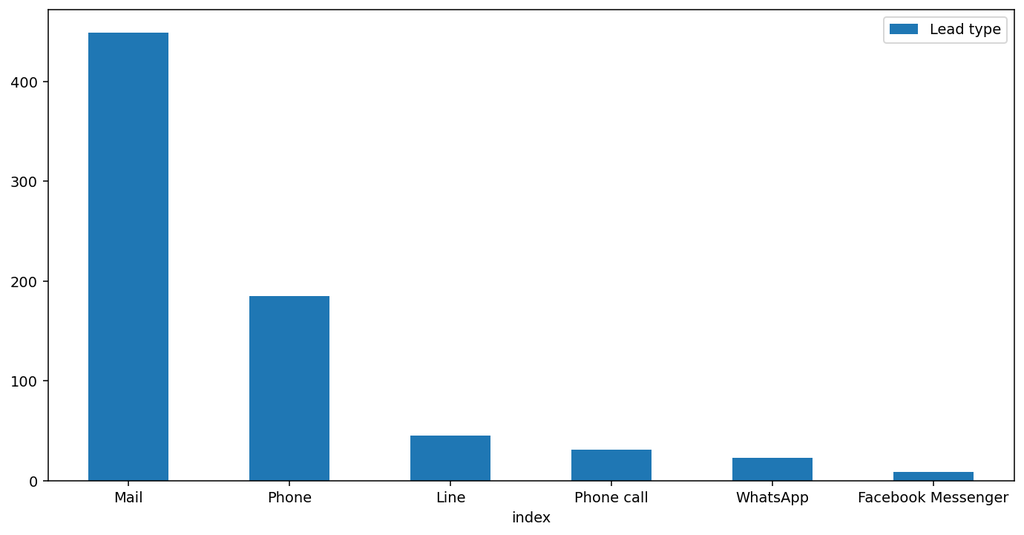

# Timelines

- Leads per Year
- Leads per Year 2022
- Leads per Year 2023
- Leads per Weekday

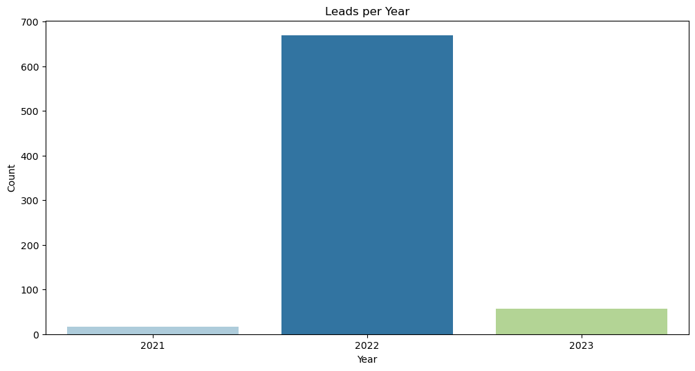

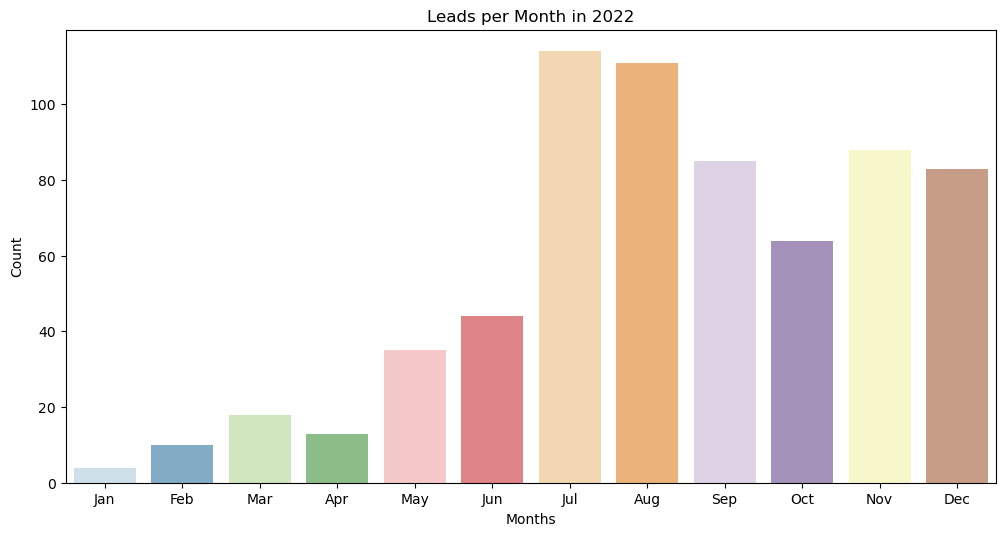

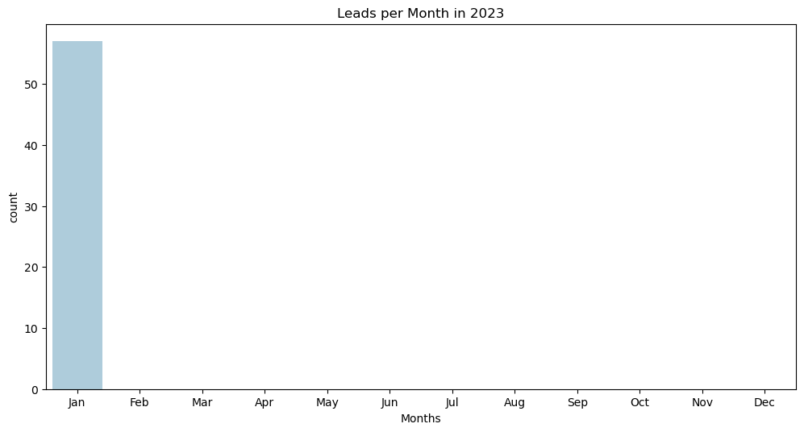

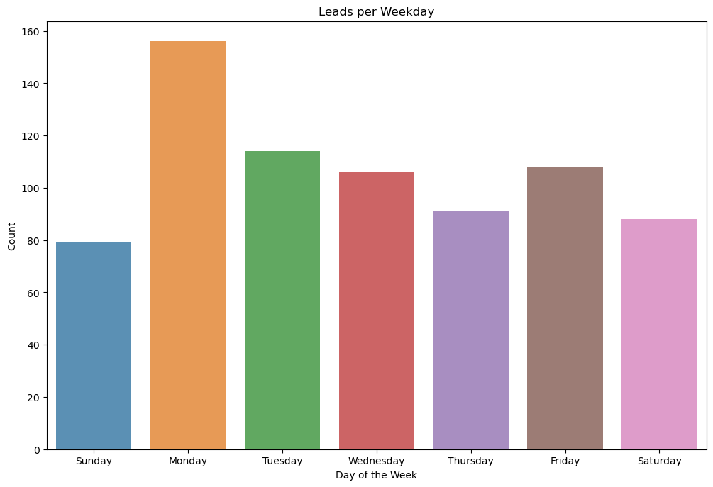